# Generación de variables aleatorias - Transformada inversa y Método del rechazo

Deimer Ivan Castillo Caceres, Iveth Medina, Rances Elith Rodriguez Lara

1 - Un par de dados balanceados serán lanzados de forma continua hasta que todos los posibles resultados 2,3, … 12 hayan ocurrido al menos una vez. Desarrolle un estudio de simulación para estimar el número esperado de lanzamientos que es necesario realizar para que se cumpla la condición.

```r
lanza_2dados <- function(){
  u1 <- runif(1)
  dado1 <- floor(6*u1)+1

  u2 <- runif(1)
  dado2 <- floor(6*u2)+1

  resultado <- dado1 + dado2
  return(resultado)
}

contador<-c()

for(i in 1:10000){
  dados<- c(2,3,4,5,6,7,8,9,10,11,12)
  k<-0
  while(length(dados)!=0){
    k=k+1
    valor<- lanza_2dados()

    if(is.element(valor,dados)){
      dados<-setdiff(dados, valor)
    }
  }

  contador<-c(contador,k)
}


paste("En promedio el numero esperado de lanzamientos que es necesario para que la condición se cumpla es: ",mean(contador))
```

```
[1] "En promedio el numero esperado de lanzamientos que es necesario para que la condición se cumpla es:  61.5182"
```

2 - Implemente dos métodos diferentes para generar la variable aleatoria X que tiene la probabilidad de masa $p_j, j=5,6,..., 14$ donde:

$p_{j} = \begin{cases} 0.11 & \text{when $j$ is odd and $5$$\le$$j$$\le$$13$}\\ 0.09 & \text{when $f$ is even and $6$$\le$$j$$\le$$14$} \end{cases}$

A partir de la definicion del enunciado podemos reescribirlo de la siguiente manera

$P\{X = j\} = 0.11$ para $j = \{5, 7, 9, 11, 13\}$

$P\{X = j\} = 0.09$ para $j = \{6, 8, 10, 12, 14\}$

usando el metodo de composicion tenemos que

$P\{X = j\} = \alpha p_{j}^1 + (\alpha - 1) p_{j}^1$

siendo

$p_{j}^1 = 5*0.11 = 0.55$

$p_{j}^2 = 5*0.09 = 0.45$

donde

$p_{j}^1 = 0.2$ para $j = \{5, 7, 9, 11, 13\}$

$p_{j}^2 = 0.2$ para $j = \{6, 8, 10, 12, 14\}$

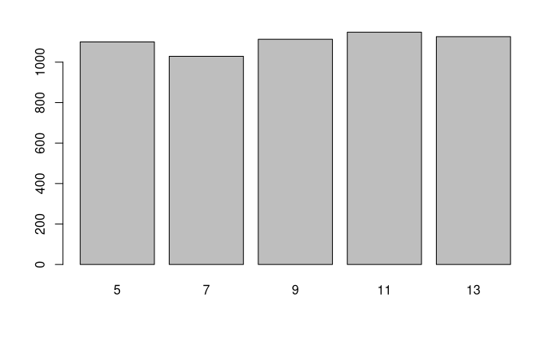

```r
n <- 10000

sample_p = vector(length = n)

for (i in 1:n){
  u1 <- runif(1)
  u2 <- runif(1)

  if(u1 > 0.55){

    if(u2<=0.2) sample_p[i] = 6
    else if(u2<=0.4) sample_p[i] = 8
    else if(u2<=0.6) sample_p[i] = 10
    else if(u2<=0.8) sample_p[i] = 12
    else sample_p[i] = 14

  }
  else{
    if(u2<=0.2) sample_p[i] = 5
    else if(u2<=0.4) sample_p[i] = 7
    else if(u2<=0.6) sample_p[i] = 9
    else if(u2<=0.8) sample_p[i] = 11
    else sample_p[i] = 13


  }

}

#samples
s_p1 <- sample_p[which(sample_p%%2==1)]
s_p2 <- sample_p[which(sample_p%%2==0)]

barplot(table(s_p1))
```

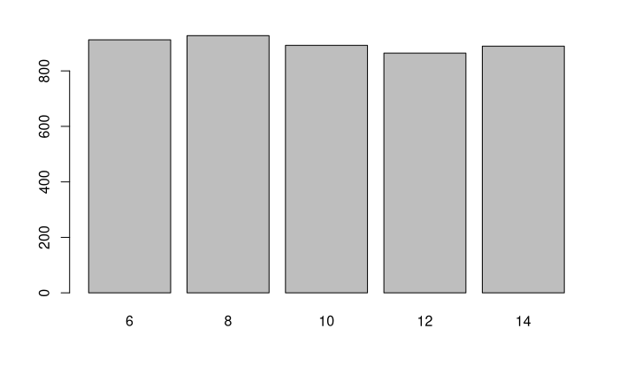

```r
barplot(table(s_p2))
```

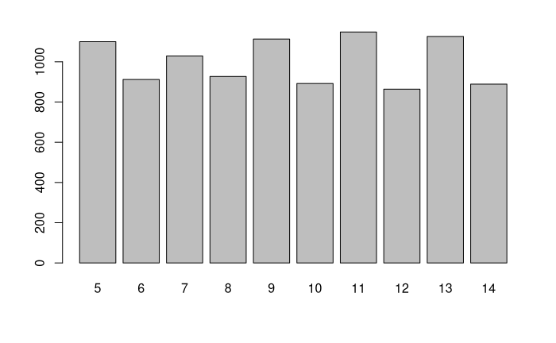

```r
barplot(table(sample_p))
```

Los diagramas de barras muestran que tanto $p_j^1$ como $p_j^2$ siguen una distribucion uniforme, la primera con valores de $\{5, 7, 9, 11, 13\}$ y la segunda con valores de $\{6, 8, 10, 12, 14\}$

3 - Implemente un método para generar valores aleatorios que siguen la distribución descrita por la función de densidad de probabilidad $f(x)=e^x/(e−1)$ para $0$$\le$$x$$\le$$1$.

Utilizando el metodo de la tranformada inversa con la funcion de densidad $f(x)$ obtenemos la funcion $F^{-1}(U)$

$F(U) = (e^x - 1)/(e - 1)$

$F^{-1}(U) = log(U(e - 1) + 1)$

Con esta funcion generamos 10000 muestras que siguen la funcion de densidad dada.

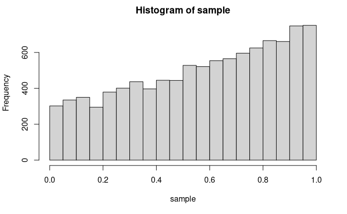

```r
n <- 10000
sample <- vector(length = n)

for (i in 1:n){
  u <-runif(1)
  sample[i] <- log( u*(exp(1) - 1) + 1 )
}

hist(sample)
```

4 - Implemente el método descrito en el ejemplo 5F del libro de Ross, que está basado en el método del rechazo, para generar una variable aleatoria con distribución normal a partir de una distribución exponencial

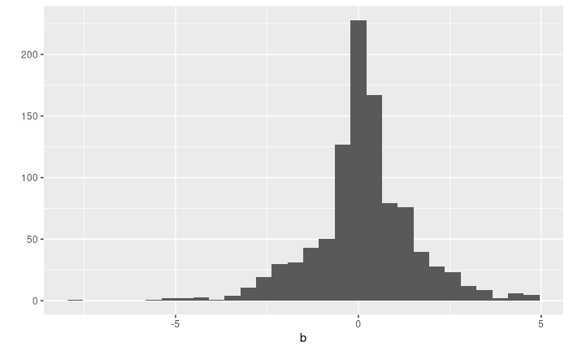

```r
library(tidyverse)

sim_exp_beta <- function(beta, n = 1000) {
  -beta * log(runif(n))
}

sim_exp<- function(n = 1000) {
  -log(runif(n))
}

cociente <- function(x){
  exp((x-1)^(2) / 2)
}

simula_normal <- function(){
  c <- sqrt(2*exp(1)/pi)
  x <- sim_exp(n = 1)
  u <- runif(1)
  while (u > cociente(x)/c) {
    u <- runif(1)
    x <- sim_exp_beta(1, n = 1)
  }
  z <- abs(x)
  if (u<=0.5) {Z <- z}
  else {Z <- -z}
}

## simulacion

b<- rerun(1000, simula_normal()) %>% flatten_dbl()
qplot(b)
```

5 - Use el método del rechazo para encontrar una forma eficiente de generar una variable aleatoria que tenga función de densidad de probabilidad $f(x)=$$\frac{1}{2}$$(1+x)e^{−x}$, $0<x<inf$. Observe que la función esta definida entre 0 e infinito.